# Администрирование сетевых подсистем

Лабораторная работа №16

Тойчубекова Асель Нурлановна

1132231842@pfur.ru

Российский университет дружбы народов

2025-12-19

# Информация

## Докладчик

- Тойчубекова Асель Нурлановна
- Студент 3 курса
- факультет физико-математических и естественных наук
- Российский университет дружбы народов им. П. Лумумбы
- 1032235033@rudn.ru

# Цель работы

## Цель работы

Целью данной лабораторной работы является получить навыки работы с программным средством Fail2ban для обеспечения базовой защиты от атак типа «brute force».

# Задание

## Задание

1. Установите и настройте Fail2ban для отслеживания работы установленных на сервере служб.
2. Проверьте работу Fail2ban посредством попыток несанкционированного доступа с клиента на сервер через SSH.
3. Напишите скрипт для Vagrant, фиксирующий действия по установке и настройке Fail2ban.

# Теоретическое введение

## Теоретическое введение

Одно из решений по защите узла сети от несанкционированного доступа и атак типа «brute force» (в частности, подбора паролей администратора методом полного перебора) -использование Fail2ban. Данное программное средство отслеживает сетевую активность на портах узла путём сканирования текстовых лог-файлов. При выявлении программой неадекватной активности какого-то узла его IP-адрес помещается в чёрный список, а все пакеты с этого адреса блокируются. Блокировка настраивается путём внесения изменений в правила межсетевого экрана.

## Теоретическое введение

Файл /etc/fail2ban/fail2ban.conf содержит настройки запуска процесса Fail2ban. Основной файл конфигурации конкретных служб в Fail2ban - /etc/fail2ban/jail.conf, настройки для локального узла должны быть размещены в файле NAMEFILE.local в каталоге /etc/fail2ban/jail.d, конфигурации для работы с различными службами размещаются в отдельных подкаталогах и файлах в каталоге /etc/fail2ban/.

## Теоретическое введение

Каждый конфигурационный файл Fail2ban имеет секции, каждая из которых описывает определённую службу и тип атаки.

## Теоретическое введение

# Выполнение лабораторной работы

## Защита с помощью Fail2ban

Для выполнения лабораторной работы запускаем вм server, заходим под нашим пользователем, открываем консоль, переходим в режим суперпользователя и устанавливаем fail2ban.

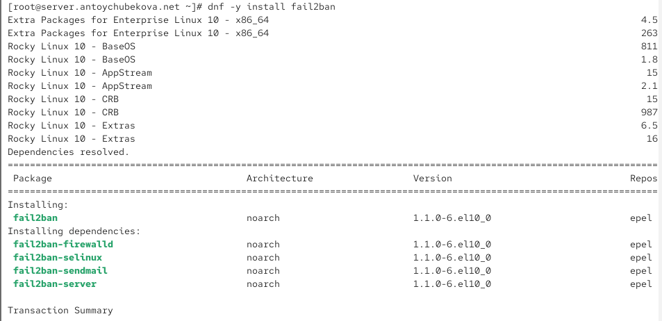

Установка fail2ban

## Защита с помощью Fail2ban

Запустим сервер fail2ban.

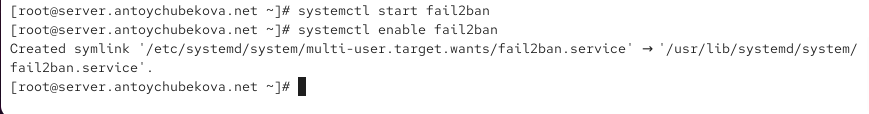

Запуск fail2ban

## Защита с помощью Fail2ban

В дополнительном терминале запустим просмотр журнала событий fail2ban. Мы видим информацию о запуске fail2ban.

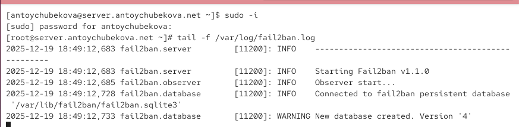

Журнал событий fail2ban

## Защита с помощью Fail2ban

Создадим файл с локальной конфигурацией fail2ban. Открываем его на редактирование и задаем время блокирования на 1 час (время задаётся в секундах), также включим защиту SSH.

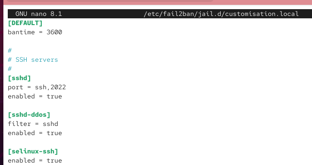

Редактирование локальной конфигурации fail2ban

## Защита с помощью Fail2ban

Перезапустим fail2ban.

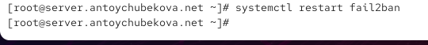

Перезапуск fail2ban

## Защита с помощью Fail2ban

Посмотрим журнал событий.

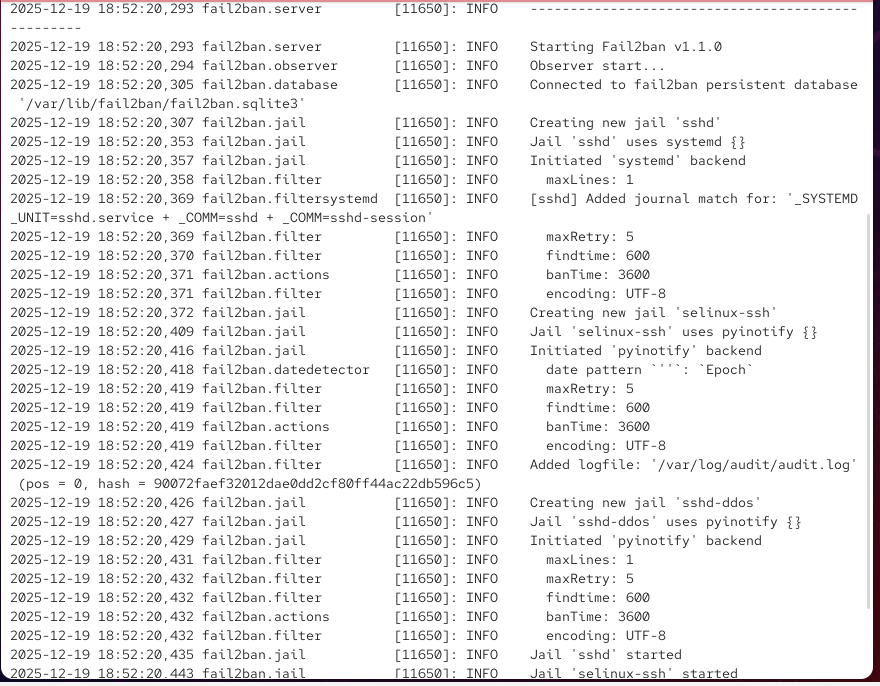

Журнал событий fail2ban

## Защита с помощью Fail2ban

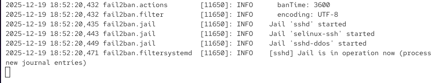

Журнал событий fail2ban

## Защита с помощью Fail2ban

В файле /etc/fail2ban/jail.d/customisation.local включим защиту HTTP.

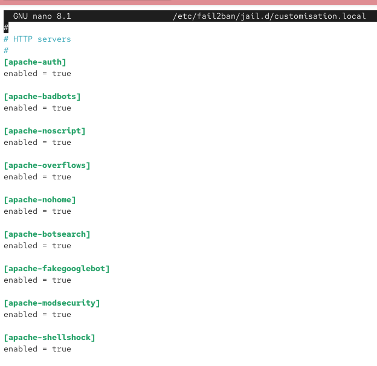

Включение защиты http

## Защита с помощью Fail2ban

Перезапустим fail2ban и просмотрим журнал событий.

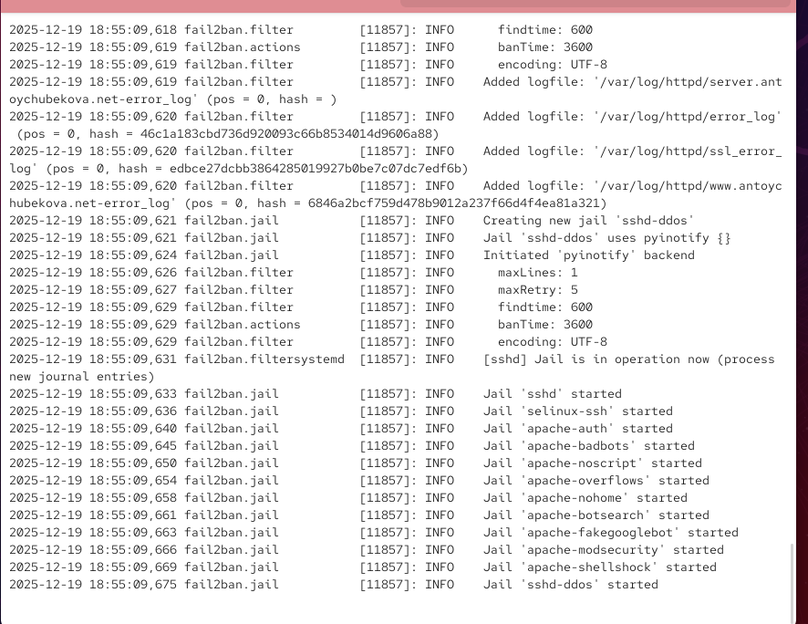

Журнал событий fail2ban

## Защита с помощью Fail2ban

В файле /etc/fail2ban/jail.d/customisation.local включим защиту почты.

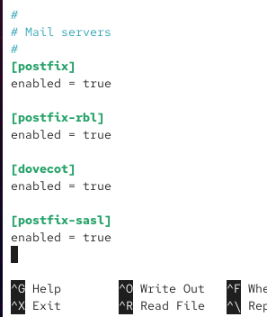

Включение защиты почты

## Защита с помощью Fail2ban

Перезапустим fail2ban.

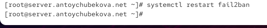

Перезапуск fail2ban

## Защита с помощью Fail2ban

Посмотрим журнал событий.

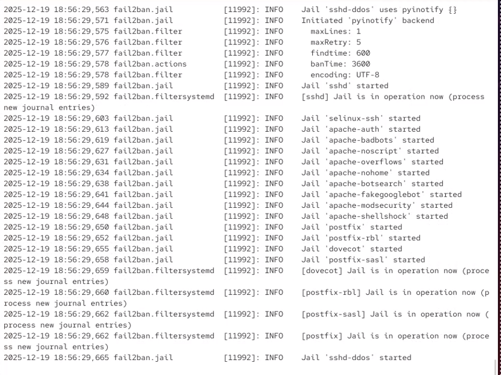

Журнал событий fail2ban

## Проверка работы Fail2ban

На сервере посмотрим статус fail2ban.

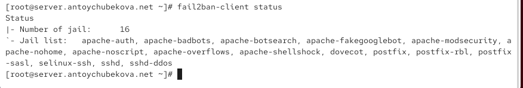

Статус fail2ban

## Проверка работы Fail2ban

Посмотрим статус защиты SSH в fail2ban.

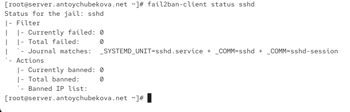

Статус защиты SSH в fail2ban

## Проверка работы Fail2ban

Установим максимальное количество ошибок для SSH, равное 2.

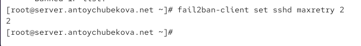

Установка максимального количество ошибок

## Проверка работы Fail2ban

С клиента попытаемся зайти по SSH на сервер с неправильным паролем. Также я прописала опции, чтобы ssh работала с паролем, а не с ключами.

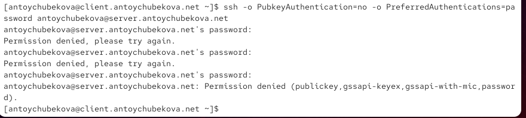

Попытка подключится по ssh к серверу

## Проверка работы Fail2ban

На сервере посмотрим статус защиты SSH.

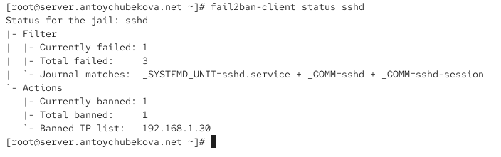

Статус защиты ssh

## Проверка работы Fail2ban

Разблокируем IP-адрес клиента.

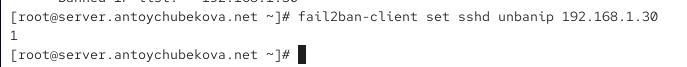

Разблокировка IP-адреса клиента

## Проверка работы Fail2ban

Вновь посмотрим статус защиты SSH, мы видим, что блокировка клиента снята.

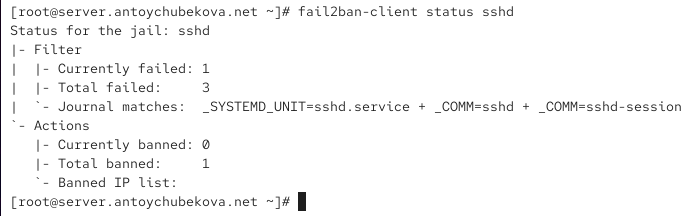

Статус защиты ssh

## Проверка работы Fail2ban

На сервере внесем изменение в конфигурационный файл /etc/fail2ban/jail.d customisation.local, добавив в раздел по умолчанию игнорирование адреса клиента.

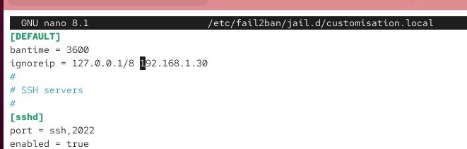

Добавление игнорирование клиена

## Проверка работы Fail2ban

Перезапустим fail2ban.

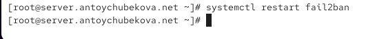

Перезапуск fail2ban

## Проверка работы Fail2ban

Посмотрим журнал событий. Мы видим, что помимо вышеописанной информации, выводится информация, что идет игнорирование клиента.

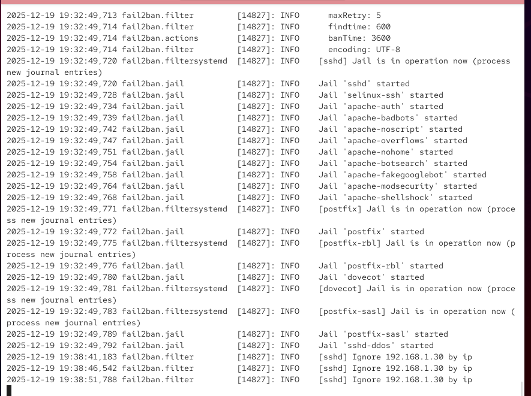

Журнал событий fail2ban

## Проверка работы Fail2ban

Вновь попытаемся войти с клиента на сервер с неправильным паролем.

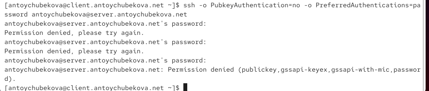

Попытка подключится к серверу с неправильным паролем

## Проверка работы Fail2ban

Далее посмотрим статус защиты ssh. Мы видим, что никакой подозрительной активности по SSH не обнаружено и клиент не заблокирован.

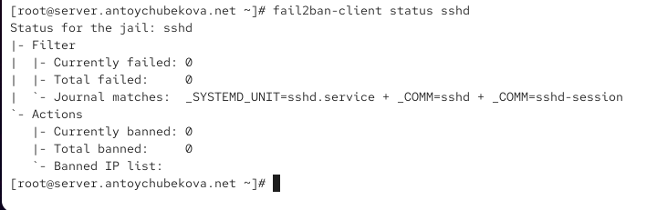

Статус защиты ssh

## Внесение изменений в настройки внутреннего окружения виртуальных машин

На виртуальной машине server перейдем в каталог для внесения изменений в настройки внутреннего окружения /vagrant/provision/server/, создадим в нём каталог protect, в который поместим в соответствующие подкаталоги конфигурационные файлы.

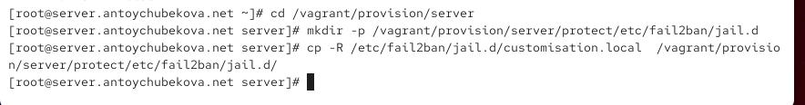

Внесение изменений в настройки внутреннего окружения виртуальных машин

## Внесение изменений в настройки внутреннего окружения виртуальных машин

В каталоге /vagrant/provision/server создадим исполняемый файл protect.sh.

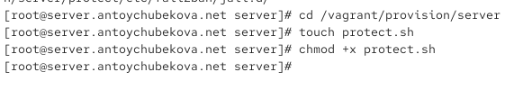

Создание исполняемого файла

## Внесение изменений в настройки внутреннего окружения виртуальных машин

Открыв его на редактирование, пропишем в нём соответствующий скрипт, фиксирующие действия по установке и настройке fail2ban.

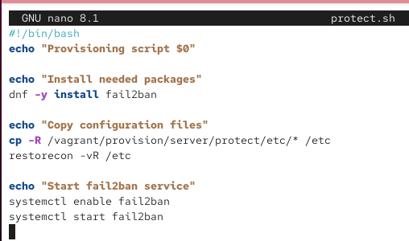

Редактирование исполняемого файла

## Внесение изменений в настройки внутреннего окружения виртуальных машин

Для отработки созданного скрипта во время загрузки виртуальной машины server в конфигурационном файле Vagrantfile добавим в соответствующем разделе конфигураций для сервера.

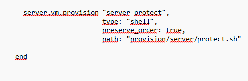

Редактирование Vagtantfile

# Выводы

## Выводы

В ходе выполнения лабораторной работы №16 я приобрела навыки работы с программным средством Fail2ban для обеспечения базовой защиты от атак типа «brute force».

# Список литературы

## Список литературы

1. Сайт Fail2ban. — URL: https://www.fail2ban.org (visited on 09/13/2021)